# 1. Exploración inicial de CERT r4.2 para detección de amenaza interna

**Trabajo (PEC3/M3.1):** Exploración inicial y validación descriptiva de fuentes  
**Máster:** Ciencia de Datos (UOC)  
**Autor:** Antonio Barrera Mora  
**Notebook:** 01_Exploracion.ipynb

**Objetivo** Realizar un análisis exploratorio del conjunto de fuentes que componen CERT r4.2 para establecer patrones de referencia, calidad de datos y decisiones metodológicas previas a la ingesta escalada (M3.2), la ingeniería de características (M3.3) y el modelado (M3.4).

**Alcance** Este notebook integra datos de actividad digital (logon, dispositivos, email y acceso a archivos) y contexto organizativo (psychometric y LDAP), manteniendo una secuencia homogénea: carga, validación, análisis temporal, distribución de actividad, cobertura de usuarios y síntesis de hallazgos.

**Table of contents**

- 1. Exploración inicial de CERT r4.2 para detección de amenaza interna
- 2. Dataset de referencia: Logon (CERT r4.2)
  - 2.1. Carga de datos
  - 2.2. Validación de calidad
  - 2.3. Análisis temporal
  - 2.4. Análisis de actividad (Logon vs Logoff)
  - 2.5. Usuarios únicos y distribución de actividad
  - 2.6. Síntesis de hallazgos (logon)
- 3. Extensión exploratoria a datasets complementarios
  - 3.1. Datasets incluidos en esta fase
  - 3.2. Dataset Device (CERT r4.2)
  - 3.3. Dataset Email (CERT r4.2) - muestreo preliminar
  - 3.4. Dataset File (CERT r4.2) - muestreo preliminar
  - 3.5. Dataset Psychometric (CERT r4.2)
- 4. Contexto organizativo: snapshots mensuales LDAP
- 5. Síntesis integrada y decisiones para la fase siguiente
  - 5.1. Hallazgos integrados: matriz de estado M3.1 vs objetivos M3.2
  - 5.2. Estado de validación y criterios de cierre de M3.2
  - 5.3. Decisiones metodológicas para continuidad
  - 5.4. Próximos hitos

# 2. Dataset de referencia: Logon (CERT r4.2)

El dataset `logon.csv` proporciona registros de inicio y cierre de sesión y se utiliza como referencia de cobertura de usuarios y coherencia temporal para contrastar el resto de fuentes.

## 2.1. Carga de datos

Cargamos el archivo y revisamos su estructura básica para validar el esquema de entrada.

```python
from pathlib import Path
import os

# Verificamos el directorio actual del kernel para que todo funcione correctamente
# y quede todo claro para futuras referencias.
# Esto es crucial para entender por que ciertas rutas relativas pueden no funcionar.
print("📍 Directorio actual del kernel (CWD):", os.getcwd())
print("📁 Ubicación esperada vs real:")
print("  Ruta relativa usada:  ../src/data/raw/logon.csv")
print("  Ruta absoluta resuelta:", (Path("..") / "src" / "data" / "raw" / "logon.csv").resolve())
```

```
📍 Directorio actual del kernel (CWD): /mnt/BackUp/01_Estudios/00_Master_ciencia_datos_UOC/TFM/TFM_Insider_Threat (trabajando)/notebooks
📁 Ubicación esperada vs real:
  Ruta relativa usada:  ../src/data/raw/logon.csv
  Ruta absoluta resuelta: /mnt/BackUp/01_Estudios/00_Master_ciencia_datos_UOC/TFM/TFM_Insider_Threat (trabajando)/src/data/raw/logon.csv
```

```python
# Verificamos la existencia del archivo
from pathlib import Path
target = Path('../src/data/raw/logon.csv')
print(f"¿Existe? {target.exists()}")
if not target.exists():
    print("Contenido real de la carpeta raw:")
    for f in sorted(target.parent.iterdir()):
        print(f"  - {f.name}")
```

```
¿Existe? True
```

```python
# Reproducibilidad: fijamos semilla para cualquier proceso aleatorio futuro
import numpy as np
random_seed = 42
np.random.seed(random_seed)
```

```python
# Importamos de librerías estndar
from pathlib import Path

# Librerias de analisis y visualización
import pandas as pd
import numpy as np
import matplotlib.pyplot as plt
import seaborn as sns

# Configuracion de visualizacion en Jupyter
%matplotlib inline
sns.set_style("whitegrid")

# Ruta al archivo raw (usamos pathlib por ser mas moderno y legible que os.path)
raw_data_path = Path('..') / 'src' / 'data' / 'raw' / 'logon.csv'
```

```python
# Cargar el dataset con parse_dates=['date'] nos evita tener que convertir la fecha despues
df_logon = pd.read_csv(raw_data_path, parse_dates=['date'])

# Inspecció rapida de dimensiones y esquema de columnas
print(f"Dimensiones del dataset: {df_logon.shape}")
print(f"\nColumnas: {df_logon.columns.tolist()}")

# Vista preliminar para validar formato, tipos de datos y coherencia visual
df_logon.head()
```

```
Dimensiones del dataset: (854859, 5)

Columnas: ['id', 'date', 'user', 'pc', 'activity']
```

|  | id | date | user | pc | activity |
| --- | --- | --- | --- | --- | --- |
| 0 | {X1D9-S0ES98JV-5357PWMI} | 2010-01-02 06:49:00 | NGF0157 | PC-6056 | Logon |
| 1 | {G2B3-L6EJ61GT-2222RKSO} | 2010-01-02 06:50:00 | LRR0148 | PC-4275 | Logon |
| 2 | {U6Q3-U0WE70UA-3770UREL} | 2010-01-02 06:53:04 | LRR0148 | PC-4124 | Logon |
| 3 | {I0N5-R7NA26TG-6263KNGM} | 2010-01-02 07:00:00 | IRM0931 | PC-7188 | Logon |
| 4 | {D1S0-N6FH62BT-5398KANK} | 2010-01-02 07:00:00 | MOH0273 | PC-6699 | Logon |

## 2.2. Validación de calidad

Verificamos tipos de datos y presencia de valores nulos para identificar riesgos tempranos de integridad.

```python
# Inspeccio general del DataFrame: tipos de datos, consumo de memoria y conteo de valores no nulos
df_logon.info()
```

```
<class 'pandas.core.frame.DataFrame'>
RangeIndex: 854859 entries, 0 to 854858
Data columns (total 5 columns):
 #   Column    Non-Null Count   Dtype
---  ------    --------------   -----
 0   id        854859 non-null  object
 1   date      854859 non-null  datetime64[ns]
 2   user      854859 non-null  object
 3   pc        854859 non-null  object
 4   activity  854859 non-null  object
dtypes: datetime64[ns](1), object(4)
memory usage: 32.6+ MB
```

```python
# Validacion de integridad: cuantificacion explícita de valores nulos (NaN) por columna
null_counts = df_logon.isnull().sum()
print("Valores nulos por columna:")
# Mostramos solo columnas con nulos para mantener la salida limpia en notebooks exploratorios
print(null_counts[null_counts > 0])
```

```
Valores nulos por columna:
Series([], dtype: int64)
```

```python
# Verificaci adicional de strings vacios o placeholders comunes
(df_logon.replace(["", "N/A", "null"], np.nan).isnull().sum())
```

```
id          0
date        0
user        0
pc          0
activity    0
dtype: int64
```

## 2.3. Análisis temporal

Identificamos el rango de fechas y la distribución temporal de registros para validar cobertura operativa del periodo de estudio.

```python
# Calculo del rango temporal: extraemos fechas minima y maxima para validar cobertura del periodo de estudio
min_date = df_logon['date'].min()
max_date = df_logon['date'].max()

# Impresión de metricas temporales clave para documentacion exploratoria
print(f"Fecha mínima: {min_date}")
print(f"Fecha máxima: {max_date}")
print(f"Duración del dataset: {(max_date - min_date).days} días")
```

```
Fecha mínima: 2010-01-02 06:49:00
Fecha máxima: 2011-05-17 06:43:35
Duración del dataset: 499 días
```

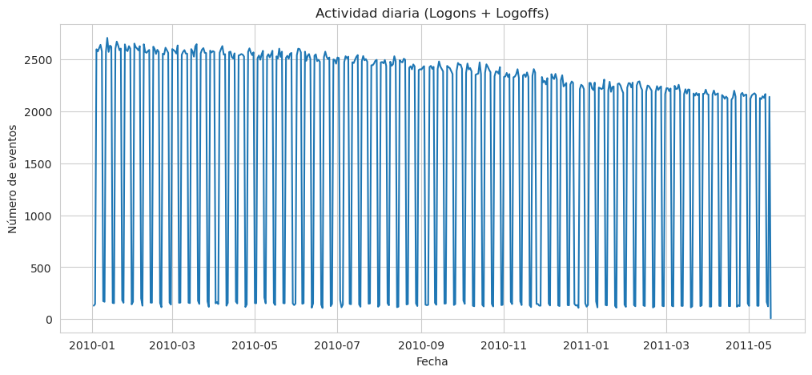

```python
# Creacion de columna auxiliar 'date_only' para agrupar por dia natural (sin hora)
# Nota: esta columna la ponemos en el DataFrame original;
# Cabe considerar uso de `.copy()` si no deseamos modificar df_logon...
df_logon['date_only'] = df_logon['date'].dt.date

# Agregacion de eventos por dia: conteo de registros para visualizar volumen diario
daily_activity = df_logon.groupby('date_only').size()

# Visualizacio de serie temporal: configuracio de figura y plot de linea
plt.figure(figsize=(12, 5))
daily_activity.plot(kind='line')
plt.title('Actividad diaria (Logons + Logoffs)')
plt.xlabel('Fecha')
plt.ylabel('Número de eventos')
plt.show()
```

## 2.4. Análisis de actividad (Logon vs Logoff)

Exploramos la variable `activity` para caracterizar la distribución de eventos y su balance operativo.

```
activity
Logon     470591
Logoff    384268
Name: count, dtype: int64
```

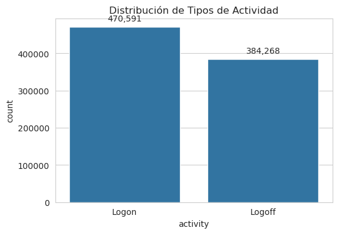

```
           Count      Pct_%
activity
Logon     470591  55.048961
Logoff    384268  44.951039
```

```python
# Distribucion absoluta de la variable categórica 'activity'
# value_counts() ordena automaticamente por frecuencia descendente
print(df_logon['activity'].value_counts())

# Grafico de distribucion mediante grafico de barras para visualizar claramente la frecuencia de cada tipo de actividad
plt.figure(figsize=(6, 4))
# La version moderna de seaborn para histogramas de categorias es countplot, que es mas eficiente y esteticamente agradable que histplot con stat='count'
# me da problemas con el shrink, asi que lo comento y uso countplot directamente
# sns.histplot(data=df_logon, x='activity', stat='count', shrink=0.8)

# seaborn cuentalas ocurrencias de cada categoria en 'activity'
sns.countplot(data=df_logon, x='activity')
ax = plt.gca()
for p in ax.patches:
    ax.annotate(f'{int(p.get_height()):,}',
                (p.get_x() + p.get_width() / 2., p.get_height()),
                ha='center', va='bottom', xytext=(0, 5), textcoords='offset points')
plt.title('Distribución de Tipos de Actividad')
plt.show()

# Salida compacta con conteo y porcentaje
activity_dist = df_logon['activity'].value_counts()
print(pd.DataFrame({'Count': activity_dist, 'Pct_%': activity_dist / len(df_logon) * 100}))
```

## 2.5. Usuarios únicos y distribución de actividad

Analizamos la cobertura de usuarios y el volumen relativo de actividad para detectar concentración de eventos y posibles sesgos de observación.

```
Número de usuarios únicos: 1000
```

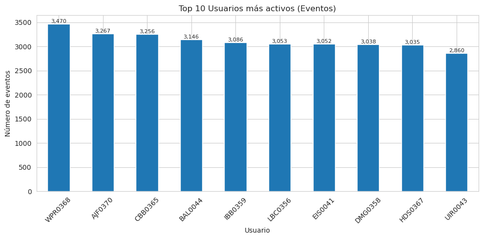

```python
# Calculo de usuarios unicos. nunique() cuenta valores distintos excluyendo NaN por defecto
unique_users = df_logon['user'].nunique()
print(f"Número de usuarios únicos: {unique_users}")

# Actividad por usuario (top 10 mas activos)
# Identificación de los 10 usuarios con mayor volumen de eventos
# value_counts() ordena automaticamente por frecuencia descendente
user_activity = df_logon['user'].value_counts().head(10)

# Visualizacio de los usuarios mas activos mediante grafico de barras
# las barras se ordenan automaticamente por frecuencia descendente,
# lo que es ideal para este caso
plt.figure(figsize=(10, 5))
user_activity.plot(kind='bar')
ax = plt.gca()
for p in ax.patches:
    ax.annotate(f'{int(p.get_width()):,}' if isinstance(user_activity.plot, type('barh')) else f'{int(p.get_height()):,}',
                (p.get_x() + p.get_width(), p.get_y() + p.get_height()/2) if isinstance(user_activity.plot, type('barh'))
                else (p.get_x() + p.get_width()/2., p.get_height()),
                ha='center' if isinstance(user_activity.plot, type('barh')) else 'center',
                va='center' if isinstance(user_activity.plot, type('barh')) else 'bottom',
                xytext=(5 if isinstance(user_activity.plot, type('barh')) else 0, 0),
                textcoords='offset points', fontsize=8)
plt.title('Top 10 Usuarios más activos (Eventos)')
plt.xlabel('Usuario')
plt.ylabel('Número de eventos')
plt.xticks(rotation=45) # Rotacion de etiquetas para mejor legibilidad
plt.tight_layout()
plt.show()
```

```python
# Verificacio de integridad: CERT r4.2 debe tener 1000 usuarios
if unique_users != 1000:
    print(f"⚠️ Alerta: se esperaban 1000 usuarios, se encontraron {unique_users}")
else:
    print("✓ Cobertura de usuarios completa (1000/1000)")
```

```
✓ Cobertura de usuarios completa (1000/1000)
```

## 2.6. Síntesis de hallazgos (logon)

Resumen operativo de cobertura, temporalidad y volumen de actividad del dataset de referencia.

```python
# Creamos un diccionario de sintesis: consolidamos métricas clave para documentación y trazabilidad del EDA
summary = {
    "Registros totales": len(df_logon), # Volumen absoluto de eventos procesados
    "Columnas": list(df_logon.columns), # Esquema final de transformaciones realizadas (incluyendo 'date_only')
    "Usuarios únicos": df_logon['user'].nunique(), # Cobertura de la poblacion de usuarios (indicador clave para analisis de insider threat y para validar integridad del dataset)
    "Rango temporal": f"{min_date} a {max_date}", # Periodo de estudio cubierto por el dataset (importante para contextualizar análisis temporales y validar que se ajusta a los objetivos del estudio)
    "Eventos Logon": len(df_logon[df_logon['activity'] == 'Logon']), # conteo explicito de eventos por tipo
    "Eventos Logoff": len(df_logon[df_logon['activity'] == 'Logoff']) # # empleable para validar balance operativo entre tipos de eventos
}

# Impresion estrcuturada del resumen para documentacion y trazabilidad del proceso exploratorio
print("Resumen exploración inicial Logon:")
for key, value in summary.items():
    print(f"  - {key}: {value}")

# Metricas adicionales para auditoria de calidad
summary["% Nulos"] = f"{df_logon.isnull().sum().sum() / df_logon.size * 100:.4f}%"
summary["Días con actividad"] = df_logon['date_only'].nunique()
summary["Ratio Logon/Logoff"] = f"{len(df_logon[df_logon['activity']=='Logon']) / len(df_logon[df_logon['activity']=='Logoff']):.2f}"

# Validaciones opcionales de integridad logica
assert summary["Usuarios únicos"] == 1000, "Cobertura de usuarios incompleta"
assert summary["Eventos Logon"] > summary["Eventos Logoff"], "Ratio Logon/Logoff inusual"
print("✓ Validaciones de coherencia superadas")
```

```
Resumen exploración inicial Logon:
  - Registros totales: 854859
  - Columnas: ['id', 'date', 'user', 'pc', 'activity', 'date_only']
  - Usuarios únicos: 1000
  - Rango temporal: 2010-01-02 06:49:00 a 2011-05-17 06:43:35
  - Eventos Logon: 470591
  - Eventos Logoff: 384268
✓ Validaciones de coherencia superadas
```

```python
# Salida en formato tabla, por si necsitamos una presentacion mas estructurada (PDF)
# y legible en notebooks exploratorios
summary_df = pd.DataFrame(list(summary.items()), columns=['Métrica', 'Valor'])
display(summary_df.style.set_properties(**{'text-align': 'left'}))
```

|  | Métrica | Valor |
| --- | --- | --- |
| 0 | Registros totales | 854859 |
| 1 | Columnas | ['id', 'date', 'user', 'pc', 'activity', 'date_only'] |
| 2 | Usuarios únicos | 1000 |
| 3 | Rango temporal | 2010-01-02 06:49:00 a 2011-05-17 06:43:35 |
| 4 | Eventos Logon | 470591 |
| 5 | Eventos Logoff | 384268 |
| 6 | % Nulos | 0.0000% |
| 7 | Días con actividad | 501 |
| 8 | Ratio Logon/Logoff | 1.22 |

# 3. Extensión exploratoria a datasets complementarios

Replicamos el mismo protocolo descriptivo (carga, validación, temporalidad, actividad, usuarios y síntesis) sobre fuentes adicionales para mantener comparabilidad metodológica con `logon.csv`.

## 3.1. Datasets incluidos en esta fase

- **Device:** conexión y desconexión de dispositivos USB y periféricos.
- **Email:** comunicaciones corporativas (muestra preliminar por chunks para exploración).
- **File:** actividad de archivos (muestra preliminar por chunks para exploración).
- **Psychometric:** rasgos Big Five OCEAN (tabla estática por usuario).
- **LDAP:** contexto organizativo mensual (snapshots históricos).

**Nota de alcance** En M3.1, email y file se exploran mediante muestra preliminar por restricciones de volumen. El procesamiento completo se aborda en M3.2 para eliminar sesgos de submuestreo.

```python
# Importacion y definicion del directorio raiz de datos raw
# pathlib garantiza compatibilidad multiplataforma y manejo seguro de rutas relativas
from pathlib import Path

# Diccionario centralizado de rutas: evita hardcodeo disperso y facilita mantenimiento
# Util para escalar a M3.2 donde anyadiremos nuevos artefactos procesados
RAW_DIR = Path('..') / 'src' / 'data' / 'raw'
DATASETS = {
    'device': RAW_DIR / 'device.csv',
    'email': RAW_DIR / 'email.csv',
    'file': RAW_DIR / 'file.csv',
    'psychometric': RAW_DIR / 'psychometric.csv',
    'ldap_dir': RAW_DIR / 'LDAP',
}

# Verificacio rápida de disponibilidad: valida que todos los archivos/directorios existen
# antes de iniciar cargas masivas, ahorrando tiempo de ejecucion si falta algun recurso
print('Rutas de trabajo:')
for name, path in DATASETS.items():
    print(f'  - {name}: {path} (existe={path.exists()})')

# Funcion auxiliar para carga eficiente de muestras preliminares
# Limita nrows para evitar saturación de RAM con email/file (>1GB) y desactiva
# inferencia de tipos mixtos (low_memory=False) para warnings de pandas
def load_preliminary_sample(csv_path, nrows=200000, parse_dates=None):
    """Carga preliminar para archivos grandes en fase exploratoria."""
    return pd.read_csv(csv_path, nrows=nrows, parse_dates=parse_dates, low_memory=False)

# Funcion auxiliar estandarizada para reporte de integridad
# Reutilizable en todos los datasets para mantener coherencia en salidas del notebook
def report_nulls(df, title='Valores nulos por columna'):
    null_counts = df.isnull().sum()
    print(title)
    print(null_counts[null_counts > 0] if (null_counts > 0).any() else 'No se detectaron nulos.')
```

```
Rutas de trabajo:
  - device: ../src/data/raw/device.csv (existe=True)
  - email: ../src/data/raw/email.csv (existe=True)
  - file: ../src/data/raw/file.csv (existe=True)
  - psychometric: ../src/data/raw/psychometric.csv (existe=True)
  - ldap_dir: ../src/data/raw/LDAP (existe=True)
```